# Industry 4.0 의 중심, AI - ML&DL

Machine Learning & Deep Learning with TensorFlow @ [FB / jskim.kr](https://www.facebook.com/jskim.kr), 김진수

# Sect5. Logistic (regression) classifier

```python
from images import bigpycraft_ai as bpc
from IPython.display import Image
from tqdm import tqdm_notebook
```

### 로지스틱 회귀 (Logistic regression)

> [위키피디어 : 로지스틱 회귀 (Logistic regression)](https://ko.wikipedia.org/wiki/%EB%A1%9C%EC%A7%80%EC%8A%A4%ED%8B%B1_%ED%9A%8C%EA%B7%80)
> - 로지스틱 회귀는 D.R.Cox가 1958년에 제안한 확률 모델로서 독립 변수의 선형 결합을 이용하여 사건의 발생 가능성을 예측하는데 사용되는 통계 기법이다.
> - 로지스틱 회귀는 선형 회귀 분석과는 다르게 종속 변수가 범주형 데이터를 대상으로 하며 입력 데이터가 주어졌을 때 해당 데이터의 결과가 특정 분류로 나뉘기 때문에 일종의 분류 (classification) 기법으로도 볼 수 있다.

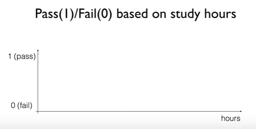

```python
# 학습시간에 따른 이항변수 결과
bpc.Figure(bpc.ML05_IMG_01, 650)
```

$$ H(X) = W X $$

$$ z = H(X) $$
$$ g(z) $$

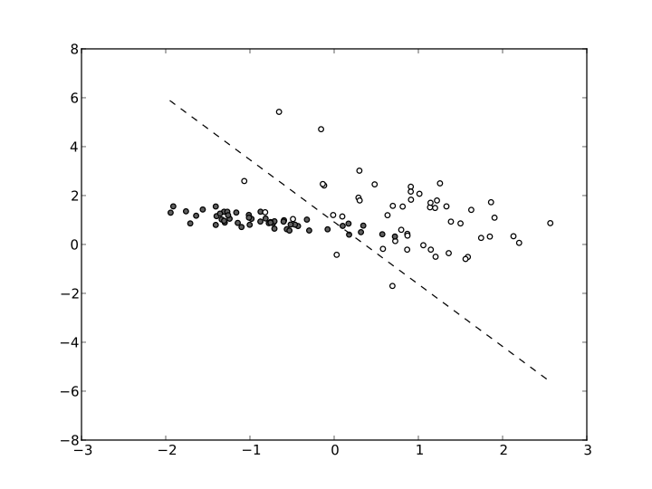

```python
# 종속변수가 이항형 문제인 경우
bpc.Figure(bpc.ML05_IMG_02)
```

### 로지스틱 함수

> - 로지스틱 모형 식은 독립 변수가 [-∞,∞]의 어느 숫자이든 상관 없이 종속 변수 또는 결과 값이 항상 범위 [0,1] 사이에 있도록 한다.
> - 이는 오즈비(odds ratio)를 로짓(logit) 변환을 수행함으로써 얻어진다

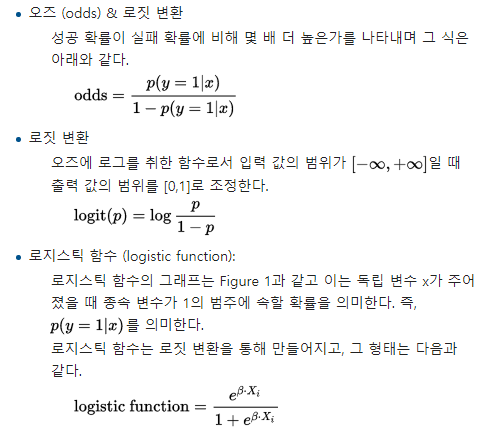

```python
# 로지스틱 함수식
bpc.Figure(bpc.ML05_IMG_03)
```

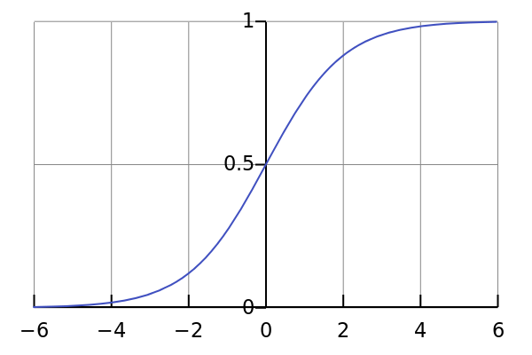

```python
bpc.Figure(bpc.ML05_IMG_04)
```

### Logistic Regression Classifier

> - Logistic Model : [holehouse.org / Logistic Regression](http://www.holehouse.org/mlclass/06_Logistic_Regression.html)
> - Cost Function : [Logistic Regression Cost Function](https://wikidocs.net/4289)

$$ H(X) = \frac{1}{1 + e^-W^TX} $$

$$ cost(W) = -\frac{1}{m} \sum y log(H(x)) + (1-y)(log(1 - H(x)) $$
$$ W := W - α \frac{σ}{σW} cost(W) $$

### Anyway, Cost를 최소화 하는 것이 최적화의 방법

> - y=1일때, 우리의 예측이 맞았다면, cost는 0  
>   H(x) = 1 → cost(1) = 0
> - y=1일때, 우리의 예측이 틀리다면, cost는 ∞  
>   H(x) = 0 → cost(0) = ∞
> - y=0일때, 우리의 예측이 맞았다면, cost는 0  
>   H(x) = 0 → cost(0) = 0
> - y=0일때, 우리의 예측이 틀리다면, cost는 ∞  
>   H(x) = 1 → cost(1) = ∞

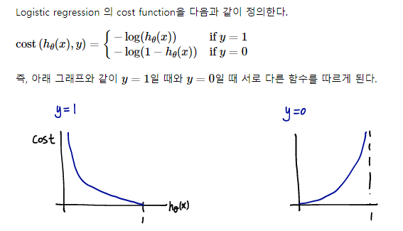

```python
# Cost function
bpc.Figure(bpc.ML05_IMG_05)
```

```python
# import tensorflow as tf
import tensorflow.compat.v1 as tf

tf.disable_v2_behavior()

tf.set_random_seed(777)  # for reproducibility

# Training Data 2dim: x1(hours), x2(attendence)
x_data = [[1, 2], [2, 3], [3, 1], [4, 3], [5, 3], [6, 2]]
# Result Data : y(0:fail or 1:pass)
y_data = [[0], [0], [0], [1], [1], [1]]

# placeholders for a tensor that will be always fed.
X = tf.placeholder(tf.float32, shape=[None, 2])
Y = tf.placeholder(tf.float32, shape=[None, 1])

W = tf.Variable(tf.random_normal([2, 1]), name='weight')
b = tf.Variable(tf.random_normal([1]), name='bias')

# Hypothesis using sigmoid: tf.div(1., 1. + tf.exp(tf.matmul(X, W)))
hypothesis = tf.sigmoid(tf.matmul(X, W) + b)

# cost/loss function
cost = -tf.reduce_mean(Y * tf.log(hypothesis) + (1 - Y) *
                       tf.log(1 - hypothesis))

train = tf.train.GradientDescentOptimizer(learning_rate=0.01).minimize(cost)

# Accuracy computation
# True if hypothesis>0.5 else False
predicted = tf.cast(hypothesis > 0.5, dtype=tf.float32)
accuracy = tf.reduce_mean(tf.cast(tf.equal(predicted, Y), dtype=tf.float32))
```

```
WARNING:tensorflow:From C:\Python\anaconda3\lib\site-packages\tensorflow\python\compat\v2_compat.py:107: disable_resource_variables (from tensorflow.python.ops.variable_scope) is deprecated and will be removed in a future version.
Instructions for updating:
non-resource variables are not supported in the long term
```

```python
# Launch graph
with tf.Session() as sess:
    # Initialize TensorFlow variables
    sess.run(tf.global_variables_initializer())

    for step in tqdm_notebook(range(10001)):
        cost_val, _ = sess.run([cost, train], feed_dict={X: x_data, Y: y_data})
        if step % 200 == 0 or step < 10 :
            print("Step : {} \t Cost : {}".format(step, cost_val))

    # Accuracy report
    h, c, a = sess.run([hypothesis, predicted, accuracy],
                       feed_dict={X: x_data, Y: y_data})
```

```
Step : 0 	 Cost : 0.7430492043495178
Step : 1 	 Cost : 0.7321328520774841
Step : 2 	 Cost : 0.72150057554245
Step : 3 	 Cost : 0.7111538052558899
Step : 4 	 Cost : 0.7010929584503174
Step : 5 	 Cost : 0.6913184523582458
Step : 6 	 Cost : 0.6818299889564514
Step : 7 	 Cost : 0.6726274490356445
Step : 8 	 Cost : 0.6637097001075745
Step : 9 	 Cost : 0.6550756096839905
Step : 200 	 Cost : 0.4218468964099884
Step : 400 	 Cost : 0.3823147714138031
Step : 600 	 Cost : 0.3591019809246063
Step : 800 	 Cost : 0.3428586423397064
Step : 1000 	 Cost : 0.33000972867012024
Step : 1200 	 Cost : 0.31902754306793213
Step : 1400 	 Cost : 0.3091982305049896
Step : 1600 	 Cost : 0.3001621663570404
Step : 1800 	 Cost : 0.29172614216804504
Step : 2000 	 Cost : 0.28377869725227356
Step : 2200 	 Cost : 0.2762506902217865
Step : 2400 	 Cost : 0.26909589767456055
Step : 2600 	 Cost : 0.26228079199790955
Step : 2800 	 Cost : 0.25577929615974426
Step : 3000 	 Cost : 0.24956989288330078
Step : 3200 	 Cost : 0.2436339110136032
Step : 3400 	 Cost : 0.2379549741744995
Step : 3600 	 Cost : 0.23251797258853912
Step : 3800 	 Cost : 0.22730910778045654
Step : 4000 	 Cost : 0.2223156839609146
Step : 4200 	 Cost : 0.21752572059631348
Step : 4400 	 Cost : 0.21292807161808014
Step : 4600 	 Cost : 0.208512544631958
Step : 4800 	 Cost : 0.20426923036575317
Step : 5000 	 Cost : 0.200189009308815
Step : 5200 	 Cost : 0.196263387799263
Step : 5400 	 Cost : 0.1924843192100525
Step : 5600 	 Cost : 0.18884430825710297
Step : 5800 	 Cost : 0.18533621728420258
Step : 6000 	 Cost : 0.18195341527462006
Step : 6200 	 Cost : 0.17868979275226593
Step : 6400 	 Cost : 0.17553932964801788
Step : 6600 	 Cost : 0.17249660193920135
Step : 6800 	 Cost : 0.1695563793182373
Step : 7000 	 Cost : 0.1667138934135437
Step : 7200 	 Cost : 0.16396445035934448
Step : 7400 	 Cost : 0.16130384802818298
Step : 7600 	 Cost : 0.15872789919376373
Step : 7800 	 Cost : 0.15623274445533752
Step : 8000 	 Cost : 0.1538149118423462
Step : 8200 	 Cost : 0.15147088468074799
Step : 8400 	 Cost : 0.14919747412204742
Step : 8600 	 Cost : 0.14699149131774902
Step : 8800 	 Cost : 0.14485017955303192
Step : 9000 	 Cost : 0.14277081191539764
Step : 9200 	 Cost : 0.14075064659118652
Step : 9400 	 Cost : 0.13878749310970306
Step : 9600 	 Cost : 0.1368788629770279
Step : 9800 	 Cost : 0.1350226253271103
Step : 10000 	 Cost : 0.13321655988693237
```

```python
print("# Hypothesis: \n{h} \n\n# Correct (Y): \n{c} \n\n# Accuracy: {a}".format(
    h = h, c = c, a = a
))
```

```
# Hypothesis:
[[0.0242024 ]
 [0.1489122 ]
 [0.27185953]
 [0.79689527]
 [0.9489273 ]
 [0.9833507 ]]

# Correct (Y):
[[0.]
 [0.]
 [0.]
 [1.]
 [1.]
 [1.]]

# Accuracy: 1.0
```

### Classifying diabetes

> 당뇨병 예측하는 실습 예제
> - 예측값이 1이면 당뇨병 O
> - 예측값이 0이면 당뇨병 X

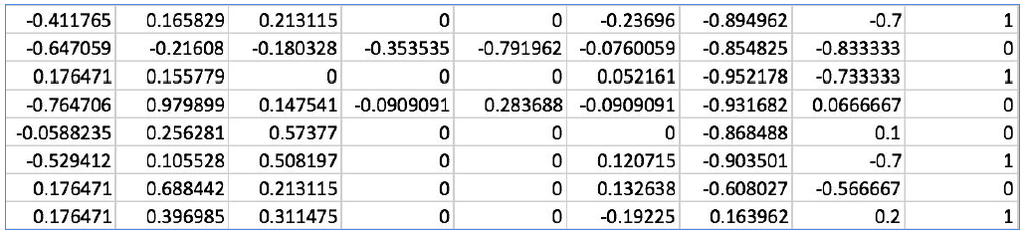

```python
# 당뇨병 분류
bpc.Figure(bpc.ML05_IMG_06, 800)
```

```python
import pandas as pd

# df = pd.read_csv("./data/data-03-diabetes.csv")
df = pd.read_csv("./data/data-03-diabetes.csv", header=None)
df.head(10)
```

|  | 0 | 1 | 2 | 3 | 4 | 5 | 6 | 7 | 8 |
| --- | --- | --- | --- | --- | --- | --- | --- | --- | --- |
| 0 | -0.294118 | 0.487437 | 0.180328 | -0.292929 | 0.000000 | 0.001490 | -0.531170 | -0.033333 | 0 |
| 1 | -0.882353 | -0.145729 | 0.081967 | -0.414141 | 0.000000 | -0.207153 | -0.766866 | -0.666667 | 1 |
| 2 | -0.058824 | 0.839196 | 0.049180 | 0.000000 | 0.000000 | -0.305514 | -0.492741 | -0.633333 | 0 |
| 3 | -0.882353 | -0.105528 | 0.081967 | -0.535354 | -0.777778 | -0.162444 | -0.923997 | 0.000000 | 1 |
| 4 | 0.000000 | 0.376884 | -0.344262 | -0.292929 | -0.602837 | 0.284650 | 0.887276 | -0.600000 | 0 |
| 5 | -0.411765 | 0.165829 | 0.213115 | 0.000000 | 0.000000 | -0.236960 | -0.894962 | -0.700000 | 1 |
| 6 | -0.647059 | -0.216080 | -0.180328 | -0.353535 | -0.791962 | -0.076006 | -0.854825 | -0.833333 | 0 |
| 7 | 0.176471 | 0.155779 | 0.000000 | 0.000000 | 0.000000 | 0.052161 | -0.952178 | -0.733333 | 1 |
| 8 | -0.764706 | 0.979899 | 0.147541 | -0.090909 | 0.283688 | -0.090909 | -0.931682 | 0.066667 | 0 |
| 9 | -0.058824 | 0.256281 | 0.573770 | 0.000000 | 0.000000 | 0.000000 | -0.868488 | 0.100000 | 0 |

```python
# Lab 5 Logistic Regression Classifier
# import tensorflow as tf
import tensorflow.compat.v1 as tf
import numpy as np

tf.disable_v2_behavior()

tf.set_random_seed(777)  # for reproducibility

xy = np.loadtxt('./data/data-03-diabetes.csv', delimiter=',', dtype=np.float32)
x_data = xy[:, 0:-1]
y_data = xy[:, [-1]]

# print(x_data.shape, y_data.shape)
print(" x_data.shape : {x_shape} \n y_data.shape : {y_shape}".format(
        x_shape = x_data.shape,
        y_shape = y_data.shape
    ))

# placeholders for a tensor that will be always fed.
X = tf.placeholder(tf.float32, shape=[None, 8])
Y = tf.placeholder(tf.float32, shape=[None, 1])

W = tf.Variable(tf.random_normal([8, 1]), name='weight')
b = tf.Variable(tf.random_normal([1]), name='bias')

# Hypothesis using sigmoid: tf.div(1., 1. + tf.exp(tf.matmul(X, W)))
hypothesis = tf.sigmoid(tf.matmul(X, W) + b)

# cost/loss function
cost = -tf.reduce_mean(Y * tf.log(hypothesis) + (1 - Y) *
                       tf.log(1 - hypothesis))

train = tf.train.GradientDescentOptimizer(learning_rate=0.01).minimize(cost)

# Accuracy computation
# True if hypothesis>0.5 else False
predicted = tf.cast(hypothesis > 0.5, dtype=tf.float32)
accuracy = tf.reduce_mean(tf.cast(tf.equal(predicted, Y), dtype=tf.float32))
```

```
 x_data.shape : (759, 8)
 y_data.shape : (759, 1)
```

```python
print(len(xy))
xy[:10]
```

```
759
```

```
array([[-0.294118  ,  0.487437  ,  0.180328  , -0.292929  ,  0.        ,
         0.00149028, -0.53117   , -0.0333333 ,  0.        ],
       [-0.882353  , -0.145729  ,  0.0819672 , -0.414141  ,  0.        ,
        -0.207153  , -0.766866  , -0.666667  ,  1.        ],
       [-0.0588235 ,  0.839196  ,  0.0491803 ,  0.        ,  0.        ,
        -0.305514  , -0.492741  , -0.633333  ,  0.        ],
       [-0.882353  , -0.105528  ,  0.0819672 , -0.535354  , -0.777778  ,
        -0.162444  , -0.923997  ,  0.        ,  1.        ],
       [ 0.        ,  0.376884  , -0.344262  , -0.292929  , -0.602837  ,
         0.28465   ,  0.887276  , -0.6       ,  0.        ],
       [-0.411765  ,  0.165829  ,  0.213115  ,  0.        ,  0.        ,
        -0.23696   , -0.894962  , -0.7       ,  1.        ],
       [-0.647059  , -0.21608   , -0.180328  , -0.353535  , -0.791962  ,
        -0.0760059 , -0.854825  , -0.833333  ,  0.        ],
       [ 0.176471  ,  0.155779  ,  0.        ,  0.        ,  0.        ,
         0.052161  , -0.952178  , -0.733333  ,  1.        ],
       [-0.764706  ,  0.979899  ,  0.147541  , -0.0909091 ,  0.283688  ,
        -0.0909091 , -0.931682  ,  0.0666667 ,  0.        ],
       [-0.0588235 ,  0.256281  ,  0.57377   ,  0.        ,  0.        ,
         0.        , -0.868488  ,  0.1       ,  0.        ]],
      dtype=float32)
```

```python
print(len(x_data))
x_data[:10]
```

```
759
```

```
array([[-0.294118  ,  0.487437  ,  0.180328  , -0.292929  ,  0.        ,
         0.00149028, -0.53117   , -0.0333333 ],
       [-0.882353  , -0.145729  ,  0.0819672 , -0.414141  ,  0.        ,
        -0.207153  , -0.766866  , -0.666667  ],
       [-0.0588235 ,  0.839196  ,  0.0491803 ,  0.        ,  0.        ,
        -0.305514  , -0.492741  , -0.633333  ],
       [-0.882353  , -0.105528  ,  0.0819672 , -0.535354  , -0.777778  ,
        -0.162444  , -0.923997  ,  0.        ],
       [ 0.        ,  0.376884  , -0.344262  , -0.292929  , -0.602837  ,
         0.28465   ,  0.887276  , -0.6       ],
       [-0.411765  ,  0.165829  ,  0.213115  ,  0.        ,  0.        ,
        -0.23696   , -0.894962  , -0.7       ],
       [-0.647059  , -0.21608   , -0.180328  , -0.353535  , -0.791962  ,
        -0.0760059 , -0.854825  , -0.833333  ],
       [ 0.176471  ,  0.155779  ,  0.        ,  0.        ,  0.        ,
         0.052161  , -0.952178  , -0.733333  ],
       [-0.764706  ,  0.979899  ,  0.147541  , -0.0909091 ,  0.283688  ,
        -0.0909091 , -0.931682  ,  0.0666667 ],
       [-0.0588235 ,  0.256281  ,  0.57377   ,  0.        ,  0.        ,
         0.        , -0.868488  ,  0.1       ]], dtype=float32)
```

```python
print(len(y_data))
y_data[:10]
```

```
759
```

```
array([[0.],
       [1.],
       [0.],
       [1.],
       [0.],
       [1.],
       [0.],
       [1.],
       [0.],
       [0.]], dtype=float32)
```

```python
# Launch graph
with tf.Session() as sess:
    # Initialize TensorFlow variables
    sess.run(tf.global_variables_initializer())

    for step in tqdm_notebook(range(10001)):
        cost_val, _ = sess.run([cost, train], feed_dict={X: x_data, Y: y_data})
        if step % 200 == 0 or step < 10 :
            print("Step : {} \t Cost : {}".format(step, cost_val))

    # Accuracy report
    h, c, a = sess.run([hypothesis, predicted, accuracy],
                       feed_dict={X: x_data, Y: y_data})
```

```
Step : 0 	 Cost : 1.0378105640411377
Step : 1 	 Cost : 1.0360039472579956
Step : 2 	 Cost : 1.0342001914978027
Step : 3 	 Cost : 1.0323994159698486
Step : 4 	 Cost : 1.0306012630462646
Step : 5 	 Cost : 1.028806209564209
Step : 6 	 Cost : 1.0270142555236816
Step : 7 	 Cost : 1.0252249240875244
Step : 8 	 Cost : 1.023438811302185
Step : 9 	 Cost : 1.0216553211212158
Step : 200 	 Cost : 0.7447590827941895
Step : 400 	 Cost : 0.600660502910614
Step : 600 	 Cost : 0.5523813962936401
Step : 800 	 Cost : 0.5376949906349182
Step : 1000 	 Cost : 0.5314603447914124
Step : 1200 	 Cost : 0.527259886264801
Step : 1400 	 Cost : 0.5237146019935608
Step : 1600 	 Cost : 0.5205262303352356
Step : 1800 	 Cost : 0.5176125764846802
Step : 2000 	 Cost : 0.5149363875389099
Step : 2200 	 Cost : 0.5124714374542236
Step : 2400 	 Cost : 0.5101962685585022
Step : 2600 	 Cost : 0.5080920457839966
Step : 2800 	 Cost : 0.5061423182487488
Step : 3000 	 Cost : 0.5043325424194336
Step : 3200 	 Cost : 0.50264972448349
Step : 3400 	 Cost : 0.5010824799537659
Step : 3600 	 Cost : 0.4996207356452942
Step : 3800 	 Cost : 0.49825519323349
Step : 4000 	 Cost : 0.49697786569595337
Step : 4200 	 Cost : 0.49578139185905457
Step : 4400 	 Cost : 0.4946592152118683
Step : 4600 	 Cost : 0.49360543489456177
Step : 4800 	 Cost : 0.49261474609375
Step : 5000 	 Cost : 0.4916823208332062
Step : 5200 	 Cost : 0.4908038079738617
Step : 5400 	 Cost : 0.4899752736091614
Step : 5600 	 Cost : 0.4891930818557739
Step : 5800 	 Cost : 0.4884539842605591
Step : 6000 	 Cost : 0.4877549409866333
Step : 6200 	 Cost : 0.4870932400226593
Step : 6400 	 Cost : 0.4864664077758789
Step : 6600 	 Cost : 0.48587217926979065
Step : 6800 	 Cost : 0.4853082299232483
Step : 7000 	 Cost : 0.4847727417945862
Step : 7200 	 Cost : 0.4842640161514282
Step : 7400 	 Cost : 0.4837803840637207
Step : 7600 	 Cost : 0.4833201467990875
Step : 7800 	 Cost : 0.482882022857666
Step : 8000 	 Cost : 0.4824647307395935
Step : 8200 	 Cost : 0.4820668697357178
Step : 8400 	 Cost : 0.4816875159740448
Step : 8600 	 Cost : 0.48132553696632385
Step : 8800 	 Cost : 0.48097994923591614
Step : 9000 	 Cost : 0.48064985871315
Step : 9200 	 Cost : 0.4803343713283539
Step : 9400 	 Cost : 0.480032742023468
Step : 9600 	 Cost : 0.47974419593811035
Step : 9800 	 Cost : 0.47946807742118835
Step : 10000 	 Cost : 0.4792037010192871
```

```python
print("# Hypothesis: \n{h} \n\n# Correct (Y): \n{c} \n\n# Accuracy: {a}".format(
    # h = h, c = c, a = a
    h = h[:20], c = c[:20], a = a
))
```

```
# Hypothesis:
[[0.3627589 ]
 [0.92355967]
 [0.29080147]
 [0.94547033]
 [0.18961821]
 [0.8234605 ]
 [0.9493171 ]
 [0.60130876]
 [0.20435551]
 [0.57932526]
 [0.72445863]
 [0.16475578]
 [0.38877195]
 [0.12278756]
 [0.7965804 ]
 [0.4620533 ]
 [0.7865777 ]
 [0.82233024]
 [0.82345665]
 [0.6144735 ]]

# Correct (Y):
[[0.]
 [1.]
 [0.]
 [1.]
 [0.]
 [1.]
 [1.]
 [1.]
 [0.]
 [1.]
 [1.]
 [0.]
 [0.]
 [0.]
 [1.]
 [0.]
 [1.]
 [1.]
 [1.]
 [1.]]

# Accuracy: 0.7694334387779236
```

The BigpyCraft find the information to design valuable society with Technology & Craft.

< The End >